# #Mimulus Genetic Mapping - A new approach with more molecular markers

Marcos Godoy e Wellingson Assunção Araújo

1 de junho de 2019

```r
library(onemap)
```

```r
mapmaker_f2 <- read_mapmaker(file="m_feb06.raw")
```

```
##  --Read the following data:
##  Type of cross:          f2
##  Number of individuals:  287
##  Number of markers:      418
##  Missing trait values:
##    fl: 11
##    fs: 19
##    ft: 11
##    ll: 20
##    nv: 12
##    pa: 35
##   pal: 11
##    pv: 12
##    sa: 11
##    sl: 11
##    ss: 28
##    tl: 11
##    tp: 12
##    tw: 11
##    vi: 12
##    ww: 11
```

```r
mapmaker_f2
```

```
##   This is an object of class 'onemap'
##     Type of cross:      f2
##     No. individuals:    287
##     No. markers:        418
##     CHROM information:  no
##     POS information:    no
##     Percent genotyped:  89
##
##     Segregation types:
##        AA : AB : BB -->  213
##         Not AA : AA -->  92
##         Not BB : BB -->  113
##
##     No. traits:         16
##     Missing trait values:
##    fl: 11
##    fs: 19
##    ft: 11
##    ll: 20
##    nv: 12
##    pa: 35
##   pal: 11
##    pv: 12
##    sa: 11
##    sl: 11
##    ss: 28
##    tl: 11
##    tp: 12
##    tw: 11
##    vi: 12
##    ww: 11
```

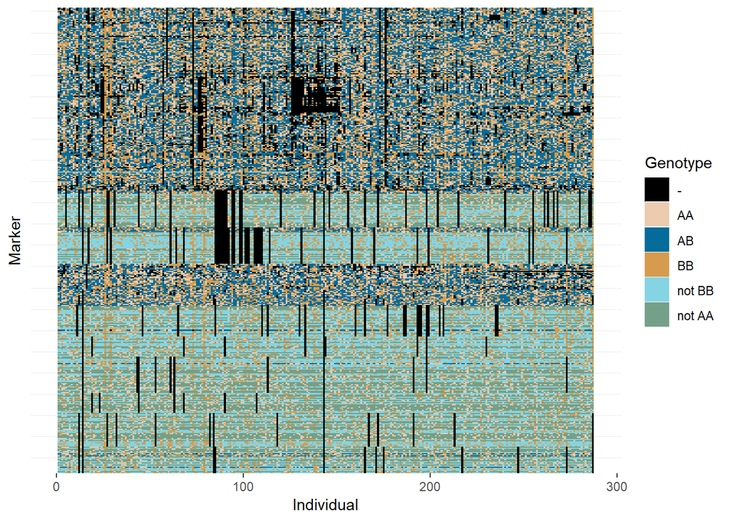

```r
plot(mapmaker_f2)
```

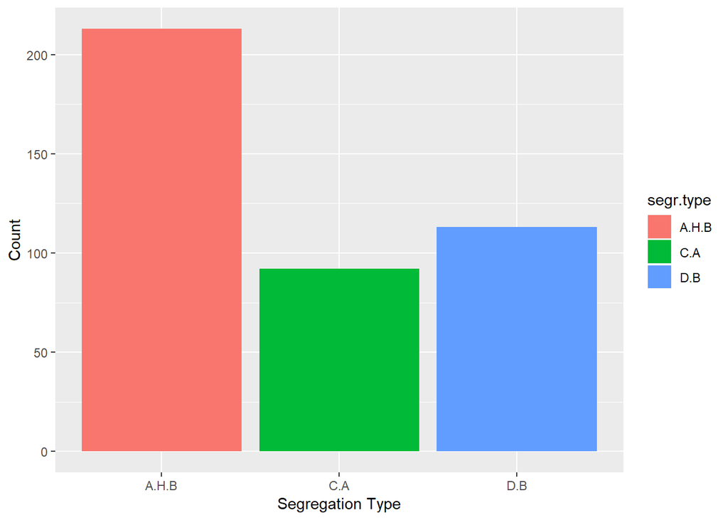

```r
plot_by_segreg_type(mapmaker_f2)
```

```r
f2_test <- test_segregation(mapmaker_f2)
print(f2_test)
```

```
##        Marker    H0   Chi-square      p-value % genot.
## 1       AA461   3:1 9.601212e+00 1.944490e-03    95.82
## 2       AA420   3:1 8.836364e-01 3.472076e-01    95.82
## 3       AA404   3:1 1.843636e+00 1.745253e-01    95.82
## 4       AA384   3:1 3.938182e+00 4.720177e-02    95.82
## 5       AA378   3:1 1.236485e+01 4.374931e-04    95.82
## 6      AA371C 1:2:1 5.392727e+00 6.745034e-02    95.82
## 7       AA361   3:1 4.810909e+00 2.828012e-02    95.82
## 8       AA341   3:1 2.241212e+00 1.343756e-01    95.82
## 9       AA311   3:1 5.441212e+00 1.966702e-02    95.82
## 10      AA280   3:1 3.404848e+00 6.500508e-02    95.82
## 11      AA277   3:1 3.503030e-01 5.539416e-01    95.82
## 12      AA270   3:1 5.441212e+00 1.966702e-02    95.82
## 13      AA268   3:1 1.484848e+00 2.230175e-01    95.82
## 14      AA246   3:1 1.090909e-02 9.168149e-01    95.82
```

[output cut: 404 more lines]

```r
Redun <- find_bins(mapmaker_f2)
```

```r
Bonferroni_alpha(f2_test)
```

```
## [1] 0.0001196172
```

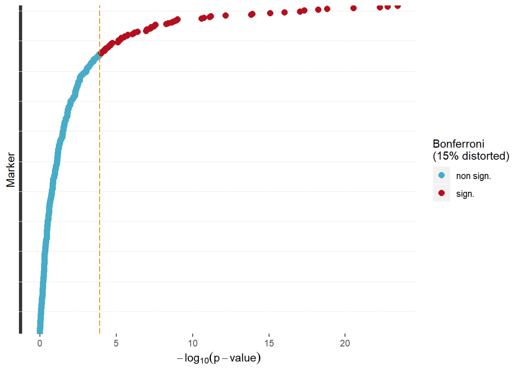

```r
plot(f2_test)
```

```r
twopts_f2 <- rf_2pts(mapmaker_f2)
```

```
## Computing 87153 recombination fractions:
##
##  0%  ........................................... 100%
```

```r
(LOD_sug <- suggest_lod(mapmaker_f2))
```

```
## [1] 5.429707
```

```r
mark_all_f2 <- make_seq(twopts_f2, "all")
```

```r
no_dist <- select_segreg(f2_test, distorted = FALSE, numbers = TRUE) #to show the markers numbers without segregation distortion
no_dist
```

```
##   [1]   1   2   3   4   5   6   7   8   9  10  11  12  13  14  15  17  18
##  [18]  19  20  21  22  23  24  25  26  27  28  29  30  32  33  34  35  36
##  [35]  37  38  39  40  42  44  45  46  47  48  50  51  52  53  54  56  57
##  [52]  58  59  60  61  62  63  64  65  66  67  68  70  71  72  73  74  75
##  [69]  76  77  78  79  80  81  82  83  84  87  88  89  90  92  93  94  95
##  [86]  96  97  98  99 100 101 102 103 104 105 106 107 108 109 110 111 112
## [103] 113 114 115 116 117 118 119 120 121 122 123 124 125 126 127 129 130
## [120] 131 132 133 134 135 137 138 139 140 142 143 144 145 146 148 149 150
## [137] 151 153 154 155 156 157 158 159 160 161 162 164 165 166 168 170 171
## [154] 172 173 174 175 179 180 181 183 184 185 186 187 188 189 190 191 192
## [171] 193 194 195 197 198 199 200 201 202 203 204 205 206 207 208 209 210
## [188] 211 212 213 214 215 216 217 218 220 221 222 223 224 225 226 227 228
## [205] 229 230 231 232 233 235 237 238 239 240 241 242 243 244 245 246 247
## [222] 248 249 250 252 253 254 255 256 257 258 259 260 262 264 267 268 269
## [239] 270 271 272 273 274 278 279 280 281 282 283 284 285 289 290 291 292
## [256] 293 295 296 297 298 299 300 301 302 303 304 306 309 310 311 312 313
## [273] 314 315 316 317 318 319 321 322 324 326 327 329 330 331 332 333 334
## [290] 336 338 340 341 342 343 344 345 347 348 349 350 351 352 354 356 357
## [307] 358 359 360 362 363 364 365 366 367 368 369 371 372 373 374 375 376
## [324] 378 381 383 384 385 386 387 388 389 390 392 395 397 398 399 400 401
## [341] 402 403 404 405 407 408 409 410 411 412 413 414 415 416 417 418
```

```r
mark_no_dist_f2 <- make_seq(twopts_f2, no_dist)
# Using only undistorted markers
```

```r
LGs_f2 <- group(mark_no_dist_f2, LOD = LOD_sug)
```

```
##    Selecting markers:
##    group    1
##     .......
##    group    2
##     ......................
##    group    3
##     ............................................................
##     .......................
##    group    4
##     .......................................
##    group    5
##     ...............
##    group    6
##     ...................................................
##    group    7
##     ................................
##    group    8
##     ..........................
##    group    9
##     .............
##    group    10
##     ......
##    group    11
##     ........................
##    group    12
##     .....................
##    group    13
##     ......
##    group    14
##     ...
```

```r
LGs_f2
```

```
##   This is an object of class 'group'
##   It was generated from the object "mark_no_dist_f2"
##
##   Criteria used to assign markers to groups:
##     LOD = 5.429707 , Maximum recombination fraction = 0.5
##
##   No. markers:            356
##   No. groups:             14
##   No. linked markers:     348
##   No. unlinked markers:   8
##
##   Printing groups:
##   Group 1 : 7 markers
##     AA461 AA341 BA416 BA374 CA174 CC447 AAT333
##
##   Group 2 : 22 markers
##     AA420 BA301 BA172 BA125 CA279 CA228 CB280 BD175 BD99 BC167 BC126 CC132 CC130 CC385C MgSTS316 MgSTS49 MgSTS106 MgSTS56 MgSTS457 MgSTS513 MgSTS589 MgSTS565
##
##   Group 3 : 83 markers
##     AA404 AA361 AA280 AA100 BA497 BA384 BA220 BA75 BB281 BB259 BB190 BB122 BB119 BB102 CA289 CA238 CA220 CA198 CA131 CA96 CB309 CB246 CB187 CB173 CB166 CB162 CB156 BD433 BD429 BD292 BD286 BD263 BD209 BD170 BD68 AA153C CA258C BB103C AAT261 AAT278 AAT374 AAT372 AG19 BC498 BC379 BC334 BC131 BC70 BC5…
##
##   Group 4 : 39 markers
##     AA384 AA166C AA66 BA210 BA113 BB208 CA497 CA415 CA399 CA384 CA297 CA233 CB329 CB257 BD411 BD243 BD239 BD130 BD115 AA346C AA374C BA279C CA183C BC512 BC321 BC216 BC192 CC531 CC270 MgSTS132 MgSTS228 MgSTS234 MgSTS455 MgSTS262 MgSTS362 MgSTS492 MgSTS347 MgSTS477 MgSTS542B
##
##   Group 5 : 15 markers
##     AA378 AA268 AA163 BA69 BB210 BB186 CB230 BD316C AA454C BC506 CC124 MgSTS40 MgSTS282A MgSTS255 MgSTS586
##
##   Group 6 : 51 markers
##     AA371C AA311 AA277 AA270 AA158 BA222 BA117 CA283 CA152C CB333 BD179 BD169 BD55 AAT230 AAT300 BC392 BC243 BC125 CC457 CC381 CC262 CC126 CC171C MgSTS21 MgSTS25 MgSTS22 MgSTS28 MgSTS105 MgSTS120 MgSTS58 MgSTS229 MgSTS323 MgSTS508 MgSTS529 MgSTS480 MgSTS426 MgSTS453 MgSTS456 MgSTS430 MgSTS314 MgS…
##
##   Group 7 : 32 markers
##     AA246 BA372 BA314 BA158 BB167 CA305 CA210 CA122 CB272 BD189C AAT217 AAT39 AAT211 AAT296 CYCB AAT242 CC450 CC359 CC338C MgSTS59 MgSTS69 MgSTS31 MgSTS76 MgSTS330 MgSTS381 MgSTS571 MgSTS590 MgSTS537 MgSTS538 MgSTS563 MgSTS504C MgSTS621
##
##   Group 8 : 26 markers
##     AA167 AA95 BA445 BA400 BA311 BB218 BB176 CA261 CA217 CA196 CA167 CB115 BA396C AAT222 BC108 BC83 CC540 CC402 LFY MgSTS468 MgSTS638 MgSTS536 MgSTS558 MgSTS611 MgSTS600 MgSTS470
##
##   Group 9 : 13 markers
##     AA137 BB216 CA75 BD371 BD251 CC93 MgSTS17 MgSTS18 MgSTS133 MgSTS350 MgSTS500 MgSTS578 MgSTS632
##
##   Group 10 : 6 markers
##     BA449 CC61 MgSTS26 MgSTS93 MgSTS344 MgSTS598
##
##   Group 11 : 24 markers
##     BA394 BA175 BB182 CA378 CA140 CB216 BD143 AA296C BA245C AAT308 AAT364 BC546 BC478 BC376 BC330 BC266 BC219 CC149 CC114 MgSTS36 MgSTS437 MgSTS113 MgSTS282B MgSTS438
##
##   Group 12 : 21 markers
##     BA334 BA145 BB198 CA315 CB172 CB126 CB55 CB263C AAT240 BC199 CC150 MgSTS55 MgSTS45 MgSTS11 MgSTS68 MgSTS326 MgSTS419 MgSTS577 MgSTS104 MgSTS622 MgSTS599
##
##   Group 13 : 6 markers
##     BA153 BD270 BC194C CC138 MgSTS98 MgSTS212
##
##   Group 14 : 3 markers
##     CA150 BC80 AP3
##
##   Unlinked markers: 8  markers
##     AA208 BB279 CA392 BC542 BC374 BC135 CC371 MgSTS23
```

```r
set_map_fun(type = "kosambi") #Genetic mapping function
```

```r
# extracting the groups individually to sort
LG1 <- make_seq(LGs_f2, 1)
LG2 <- make_seq(LGs_f2, 2)
LG3 <- make_seq(LGs_f2, 3)
LG4<- make_seq(LGs_f2, 4)
LG5 <- make_seq(LGs_f2, 5)
LG6 <- make_seq(LGs_f2, 6)
LG7 <- make_seq(LGs_f2, 7)
LG8 <- make_seq(LGs_f2, 8)
LG9 <- make_seq(LGs_f2, 9)
LG10 <- make_seq(LGs_f2, 10)
LG11 <- make_seq(LGs_f2, 11)
LG12 <- make_seq(LGs_f2, 12)
LG13 <- make_seq(LGs_f2, 13)
LG14 <- make_seq(LGs_f2, 14)
```

```r
# Ordering of genetic markers
LG2_ord <- order_seq(input.seq = LG2, n.init = 7,
                        subset.search = "twopt",
                        twopt.alg = "rcd", THRES = 3)
```

```
##
## Cross type:  f2
## Choosing initial subset using 'two-point' approach
##
## order obtained using RCD algorithm:
##
##  50 252 2 245 90 296 38 209 345 302 315 109 45 140 317 369 348 388 244 212 148 84
##
## calculating multipoint map using tol =  0.1 .
##
## WARNING: this operation may take a VERY long time
##
## Comparing 2520 orders:
##
##
##
##
##
## Running try algorithm
## 315 --> MgSTS106  : ........
## 369 --> MgSTS589  : .........
## 252 --> CC385C    : .........
## 302 --> MgSTS49   : .........
## 348 --> MgSTS513  : .........
## 296 --> MgSTS316  : ..........
## 345 --> MgSTS457  : ...........
##  90 --> CA228     : ............
##  38 --> BA301     : ............
##  45 --> BA172     : ............
## 212 --> BC126     : ............
##   2 --> AA420     : .............
## 140 --> BD175     : ..............
## 148 --> BD99      : ...............
## 244 --> CC132     : ...............
##
## LOD threshold = 3
##
## Positioned markers: 50 2 245 296 209 109 315 345 140 317 388 348 212 84
##
## Markers not placed on the map: 38 45 90 148 244 252 302 369
```

[output cut: 9 more lines]

```
## 302 --> MgSTS49   : ...............
## 369 --> MgSTS589  : ...............
##
##
## Placing remaining marker(s) at most likely position
##  38 --> BA301     : ...............
## 369 --> MgSTS589  : ................
## 244 --> CC132     : .................
## 302 --> MgSTS49   : ..................
##  45 --> BA172     : ...................
## 252 --> CC385C    : ....................
##  90 --> CA228     : .....................
## 148 --> BD99      : ......................
##
## Estimating final genetic map using tol = 10E-5.
```

```r
LG2_ord
```

```
##
## Best sequence found.
## Printing map:
##
## Markers               Position
##
##  50 BA125                 0.00
##   2 AA420                10.24
## 245 CC130                19.68
## 296 MgSTS316             27.52
## 209 BC167                53.36
## 109 CB280                64.58
## 315 MgSTS106             67.89
## 345 MgSTS457             72.18
## 140 BD175                76.18
## 317 MgSTS56              80.26
## 388 MgSTS565             92.05
## 348 MgSTS513             93.51
## 212 BC126               103.75
##  84 CA279               132.99
##
##  14 markers            log-likelihood: -1562.206
##
##
##
## The following markers could not be uniquely positioned.
## Printing most likely positions for each unpositioned marker:
##
## -------------------------------------------------------
## |     |  38 |  45 |  90 | 148 | 244 | 252 | 302 | 369 |
## |-----|-----|-----|-----|-----|-----|-----|-----|-----|
## |     |     |     |     |     |     | *** |     |     |
## |  50 |     |     |     |     |     |     |     |     |
## |     |     |     |     |     |     | **  |     |     |
## |   2 |     |     |     |     |     |     |     |     |
## |     |     |     | **  |     |     |     |     |     |
## | 245 |     |     |     |     |     |     |     |     |
## |     |     |     | *** |     |     |     |     |     |
## | 296 |     |     |     |     |     |     |     |     |
## |     | *** |     |     |     |     |     |     |     |
```

[output cut: 12 more lines]

```
## | 388 |     |     |     |     |     |     |     |     |
## |     |     |     |     |     |     |     |     |     |
## | 348 |     |     |     |     |     |     |     |     |
## |     |     |     |     | *** | *   |     |     |     |
## | 212 |     |     |     |     |     |     |     |     |
## |     |     |     |     | **  | *   |     |     |     |
## |  84 |     |     |     |     |     |     |     |     |
## |     |     |     |     |     |     |     |     |     |
## -------------------------------------------------------
##
## '***' indicates the most likely position(s) (LOD = 0.0)
##
## '**' indicates very likely positions (LOD > -1.0)
##
## '*' indicates likely positions (LOD > -2.0)
```

```r
LG2_ORD_all<- make_seq(LG2_ord, "force")
LG2_ORD_all
```

```
##
## Printing map:
##
## Markers               Position
##
## 252 CC385C                0.00
##  50 BA125                13.96
##   2 AA420                21.28
## 245 CC130                31.80
##  90 CA228                33.43
## 296 MgSTS316             40.51
##  38 BA301                71.28
## 209 BC167                81.30
##  45 BA172                88.99
## 109 CB280                90.82
## 302 MgSTS49              96.17
## 315 MgSTS106             97.07
## 345 MgSTS457            101.69
## 140 BD175               106.01
## 317 MgSTS56             110.66
## 369 MgSTS589            111.43
## 244 CC132               120.76
## 388 MgSTS565            126.91
## 348 MgSTS513            128.34
## 148 BD99                137.89
## 212 BC126               138.50
##  84 CA279               167.72
##
##  22 markers            log-likelihood: -2142.921
```

```r
LG2_safe  <- make_seq ( LG2_ord , "safe" )
LG2_safe
```

```
##
## Printing map:
##
## Markers               Position
##
##  50 BA125                 0.00
##   2 AA420                10.24
## 245 CC130                19.68
## 296 MgSTS316             27.52
## 209 BC167                53.36
## 109 CB280                64.58
## 315 MgSTS106             67.89
## 345 MgSTS457             72.18
## 140 BD175                76.18
## 317 MgSTS56              80.26
## 388 MgSTS565             92.05
## 348 MgSTS513             93.51
## 212 BC126               103.75
##  84 CA279               132.99
##
##  14 markers            log-likelihood: -1562.206
```

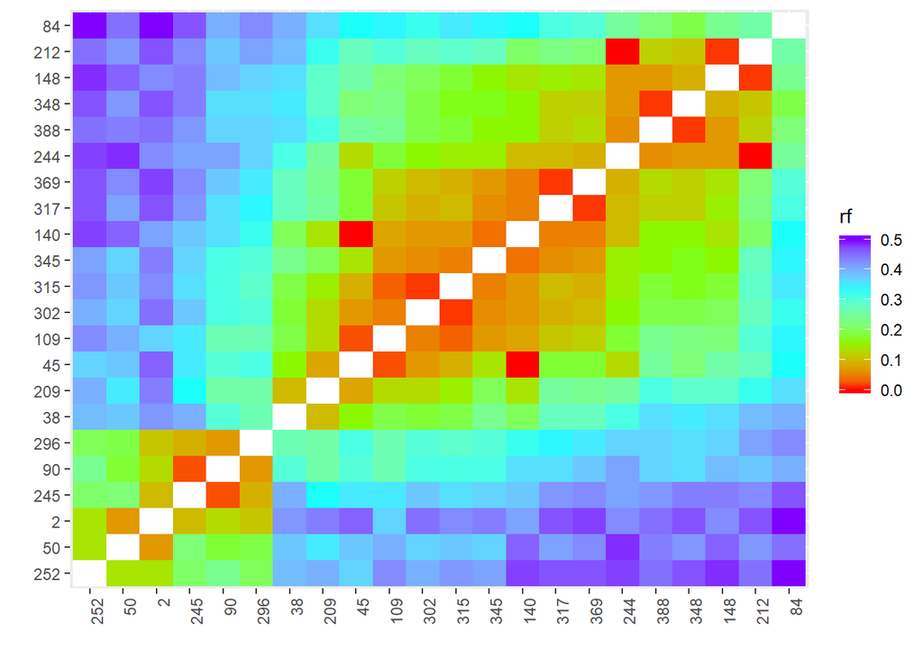

```r
rf_graph_table(LG2_ORD_all)
```

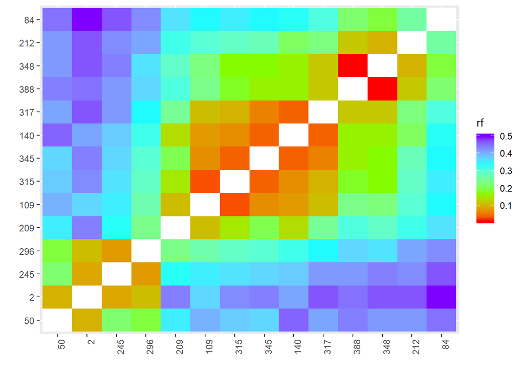

```r
rf_graph_table(LG2_safe)
```

```r
temp_seq <- drop_marker(LG2_ORD_all, 244)
temp_map <- map(temp_seq)
(temp_try <- try_seq(temp_map, 244))
```

```
## 244 --> CC132     : ......................
```

```
##
## LOD scores correspond to the best linkage phase combination
## for each position
##
## The symbol "*" outside the box indicates that more than one
## linkage phase is possible for the corresponding position
##
##
##        Marker tested: 244
##
##        Markers      LOD
##      ======================
##      |                    |
##      |            -39.52  |  1
##      |  252               |
##      |            -74.49  |  2
##      |   50               |
##      |            -72.14  |  3
##      |    2               |
##      |            -80.86  |  4
##      |  245               |
##      |            -80.55  |  5
##      |   90               |
##      |            -88.13  |  6
##      |  296               |
##      |            -37.31  |  7
##      |   38               |
##      |            -47.30  |  8
##      |  209               |
##      |            -40.45  |  9
##      |   45               |
##      |            -39.15  |  10
##      |  109               |
##      |            -52.93  |  11
##      |  302               |
##      |            -70.08  |  12
##      |  315               |
##      |            -48.26  |  13
##      |  345               |
##      |            -34.53  |  14
##      |  140               |
##      |            -26.76  |  15
##      |  317               |
##      |            -42.38  |  16
##      |  369               |
##      |             -1.28  |  17
##      |  388               |
##      |            -23.12  |  18
##      |  348               |
##      |              0.00  |  19
##      |  148               |
##      |             -4.62  |  20
##      |  212               |
##      |             -6.13  |  21
##      |   84               |
##      |            -28.37  |  22
##      |                    |
##      ======================
```

```r
(LG2_parc <- make_seq(temp_try, 19))
```

```
##
## Printing map:
##
## Markers               Position
##
## 252 CC385C                0.00
##  50 BA125                14.49
##   2 AA420                27.87
## 245 CC130                37.41
##  90 CA228                37.61
## 296 MgSTS316             45.07
##  38 BA301                78.19
## 209 BC167                88.51
##  45 BA172                96.46
## 109 CB280                96.68
## 302 MgSTS49             102.71
## 315 MgSTS106            103.62
## 345 MgSTS457            108.23
## 140 BD175               112.90
## 317 MgSTS56             117.40
## 369 MgSTS589            118.11
## 388 MgSTS565            130.51
## 348 MgSTS513            131.96
## 244 CC132               138.38
## 148 BD99                144.62
## 212 BC126               144.78
##  84 CA279               174.82
##
##  22 markers            log-likelihood: -2143.135
```

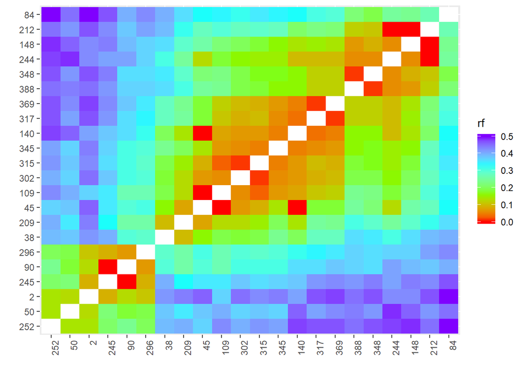

```r
rf_graph_table(LG2_parc)
```

```r
LG2_final<-drop_marker(LG2_parc, c(38, 84))
LG2_final <- map(LG2_final)
LG2_final
```

```
##
## Printing map:
##
## Markers               Position
##
## 252 CC385C                0.00
##  50 BA125                13.95
##   2 AA420                21.36
## 245 CC130                31.96
##  90 CA228                33.22
## 296 MgSTS316             40.37
## 209 BC167                66.33
##  45 BA172                74.20
## 109 CB280                76.57
## 302 MgSTS49              81.73
## 315 MgSTS106             82.63
## 345 MgSTS457             87.25
## 140 BD175                91.58
## 317 MgSTS56              96.24
## 369 MgSTS589             96.97
## 388 MgSTS565            109.28
## 348 MgSTS513            110.74
## 244 CC132               117.00
## 148 BD99                123.03
## 212 BC126               123.03
##
##  20 markers            log-likelihood: -1906.014
```

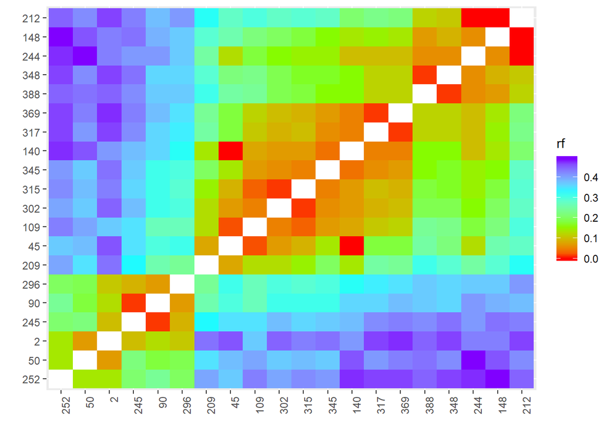

```r
rf_graph_table(LG2_final)
```

###############LG1#########

```r
LG1_ord <- order_seq(input.seq = LG1, n.init = 7,
                        subset.search = "twopt",
                        twopt.alg = "rcd", THRES = 3)
```

```
##    Length of sequence  LG1  is less than n.init
##    Returning the best order using compare function:
## WARNING: this operation may take a VERY long time
##
## Comparing 2520 orders:
##
##
```

```r
LG1_final<- make_seq(LG1_ord, "force")
LG1_final
```

```
##
## Printing map:
##
## Markers             Position
##
##   8 AA341               0.00
##  33 BA374              10.67
## 226 CC447              17.81
##   1 AA461              25.68
##  28 BA416              39.84
##  97 CA174              48.25
## 258 AAT333             57.87
##
##  7 markers            log-likelihood: -761.4381
```

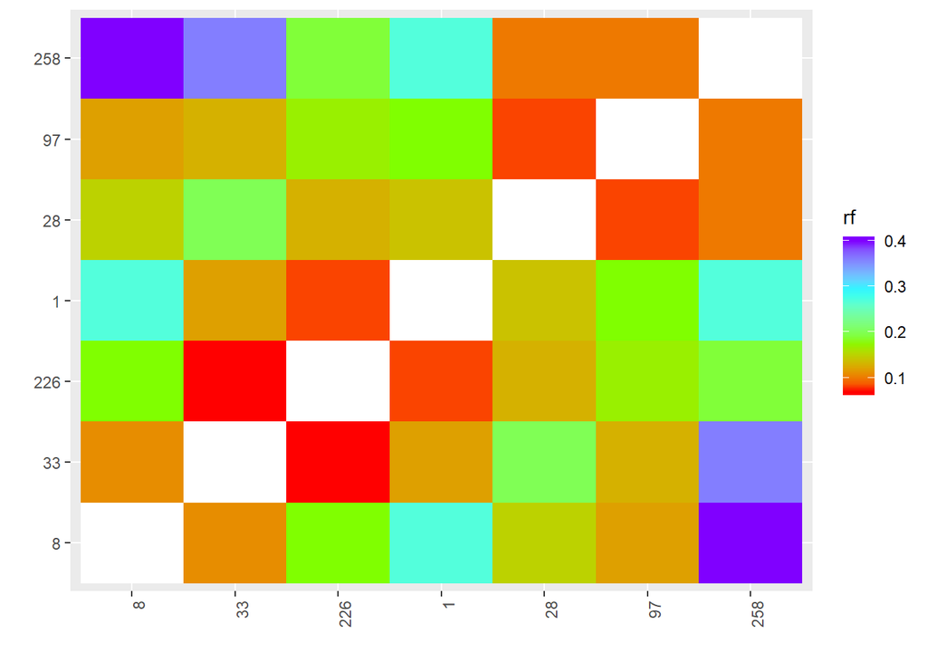

```r
rf_graph_table(LG1_final)
```

#####################LG3#########################

```r
LG3_ord <- order_seq(input.seq = LG3, n.init = 7,
                        subset.search = "twopt",
                        twopt.alg = "rcd", THRES = 3)
```

```
##
## Cross type:  f2
## Choosing initial subset using 'two-point' approach
##
## order obtained using RCD algorithm:
##
##  184 364 88 217 255 130 218 3 125 229 102 53 118 115 32 120 92 237 131 313 413 231 319 372 322 235 72 168 200 356 341 142 71 40 138 238 162 365 10 116 165 112 7 119 221 405 211 193 56 197 397 326 349 269 70 133 82 175 171 58 357 22 299 376 95 153 124 329 408 108 256 295 366 360 25 228 386 179 64 …
##
## calculating multipoint map using tol =  0.1 .
##
## WARNING: this operation may take a VERY long time
##
## Comparing 2520 orders:
##
##
```

[output cut: 190 more lines]

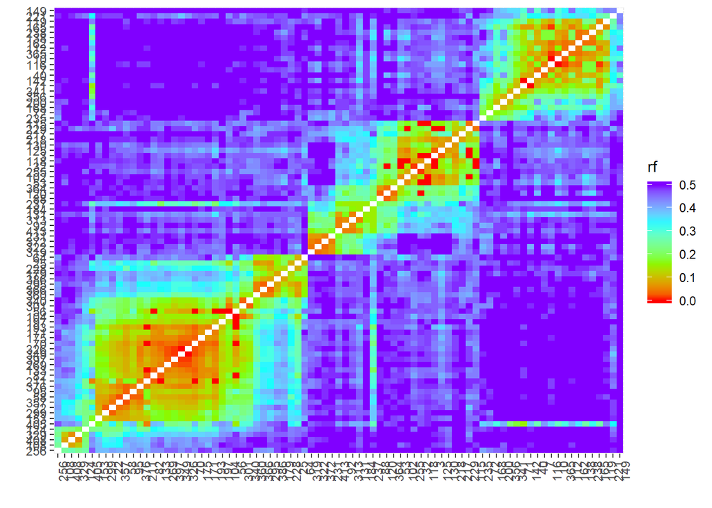

```r
LG3_ORD_all<- make_seq(LG3_ord, "force")
LG3_safe<-make_seq(LG3_ord, "safe")
rf_graph_table(LG3_ORD_all)
```

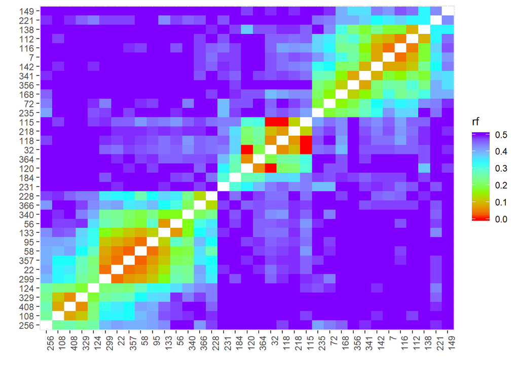

```r
rf_graph_table(LG3_safe)
```

# Apparently we have 3 groups within group 3, we will remove some marks that seem to disrupt the mapping by joining the 3 groups

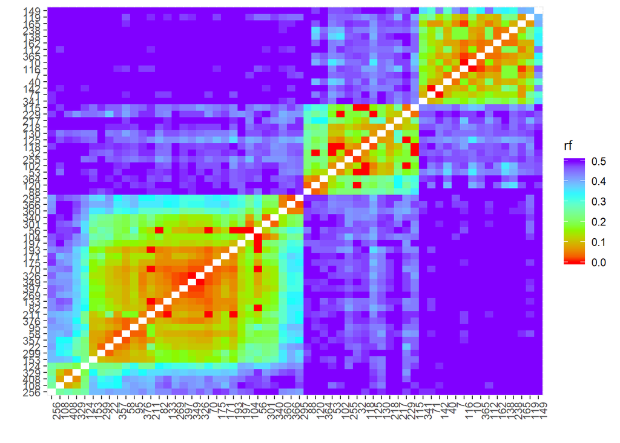

```r
LG3_final<-drop_marker(LG3_ORD_all, c(92,168,200,405,221,72,235,322,319,356,313,131,184,64,25,228,179,386,237,413,105,3,372,231))
LG3_final <- map(LG3_final)
rf_graph_table(LG3_final)
```

# We can see the presence of 3 very distinct groups within group 3, so we will use the group function to separate them

```r
Group3 <- group(LG3_final, LOD = LOD_sug)
```

```
##    Selecting markers:
##    group    1
##     ...............................
##    group    2
##     ..............
##    group    3
##     ...............
```

```r
Group3
```

```
##   This is an object of class 'group'
##   It was generated from the object "LG3_final"
##
##   Criteria used to assign markers to groups:
##     LOD = 5.429707 , Maximum recombination fraction = 0.5
##
##   No. markers:            60
##   No. groups:             3
##   No. linked markers:     60
##   No. unlinked markers:   0
##
##   Printing groups:
##   Group 1 : 31 markers
##     AAT283 CB309 MgSTS511 MgSTS332 BD433 AA153C MgSTS43 AA100 MgSTS351 BB259 CA198 MgSTS539 BC131 CA289 BD263 MgSTS27 MgSTS383 MgSTS509 MgSTS388 BB122 AAT374 AAT278 BC498 BC379 CA96 BB281 MgSTS48 MgSTS37 MgSTS293 MgSTS579 MgSTS308
##
##   Group 2 : 14 markers
##     CA238 CB156 MgSTS574B BA75 CA131 AAT312 BA384 CB166 BD429 BD292 BC586C BC70 CC387 CB187
##
##   Group 3 : 15 markers
##     MgSTS34 BB119 BD170 BA220 AA361 CB173 AA280 MgSTS574a CB246 CA258C BD209 CC283 BB103C CB162 BD68
```

```r
LG3.1 <- make_seq(Group3, 1)
LG3.2 <- make_seq(Group3, 2)
LG3.3<- make_seq(Group3, 3)
```

#Ordering the 3 groups from the old group 3.

```r
LG3.1_ord <- order_seq(input.seq = LG3.1, n.init = 7,
                        subset.search = "twopt",
                        twopt.alg = "rcd", THRES = 3)
```

```
##
## Cross type:  f2
## Choosing initial subset using 'two-point' approach
##
## order obtained using RCD algorithm:
##
##  256 108 408 329 124 153 95 376 299 22 357 58 171 82 175 269 397 349 326 70 133 211 193 56 197 104 301 340 360 366 295
##
## calculating multipoint map using tol =  0.1 .
##
## WARNING: this operation may take a VERY long time
##
## Comparing 2520 orders:
##
##
##
##
##
## Running try algorithm
## 175 --> AAT374    : ........
## 397 --> MgSTS383  : .........
## 171 --> AAT278    : .........
## 376 --> MgSTS539  : .........
## 360 --> MgSTS293  : ..........
## 408 --> MgSTS511  : ...........
## 349 --> MgSTS509  : ...........
## 301 --> MgSTS48   : ...........
## 299 --> MgSTS43   : ............
## 340 --> MgSTS37   : .............
## 326 --> MgSTS388  : ..............
## 366 --> MgSTS579  : ..............
## 329 --> MgSTS332  : ..............
##  56 --> BB281     : ..............
## 108 --> CB309     : ..............
## 124 --> BD433     : ..............
## 211 --> BC131     : ...............
##  58 --> BB259     : ................
##  70 --> BB122     : ................
##  95 --> CA198     : ................
##  82 --> CA289     : .................
```

[output cut: 30 more lines]

```
## 329 --> MgSTS332  : ...................
## 171 --> AAT278    : ....................
## 408 --> MgSTS511  : .....................
## 366 --> MgSTS579  : ......................
##  58 --> BB259     : .......................
## 108 --> CB309     : ........................
##  70 --> BB122     : .........................
##  22 --> AA100     : ..........................
## 349 --> MgSTS509  : ...........................
## 397 --> MgSTS383  : ............................
##  82 --> CA289     : .............................
## 326 --> MgSTS388  : ..............................
## 193 --> BC498     : ...............................
##
## Estimating final genetic map using tol = 10E-5.
```

```r
LG3.2_ord <- order_seq(input.seq = LG3.2, n.init = 7,
                        subset.search = "twopt",
                        twopt.alg = "rcd", THRES = 3)
```

```
##
## Cross type:  f2
## Choosing initial subset using 'two-point' approach
##
## order obtained using RCD algorithm:
##
##  88 120 364 130 218 125 229 102 118 115 32 53 255 217
##
## calculating multipoint map using tol =  0.1 .
##
## WARNING: this operation may take a VERY long time
##
## Comparing 2520 orders:
##
##
##
##
##
## Running try algorithm
## 255 --> AAT312    : ........
## 120 --> CB156     : .........
## 125 --> BD429     : .........
## 130 --> BD292     : .........
## 118 --> CB166     : ..........
##  32 --> BA384     : ..........
## 229 --> CC387     : ..........
##
## LOD threshold = 3
##
## Positioned markers: 364 88 53 102 255 130 218 115 217
##
## Markers not placed on the map: 120 32 118 125 229
##
##
## Calculating LOD-Scores
## 120 --> CB156     : ..........
##  32 --> BA384     : ..........
## 118 --> CB166     : ..........
## 125 --> BD429     : ..........
## 229 --> CC387     : ..........
##
##
## Placing remaining marker(s) at most likely position
## 125 --> BD429     : ..........
## 229 --> CC387     : ...........
## 118 --> CB166     : ............
##  32 --> BA384     : .............
## 120 --> CB156     : ..............
##
## Estimating final genetic map using tol = 10E-5.
```

```r
LG3.3_ord <- order_seq(input.seq = LG3.3, n.init = 7,
                        subset.search = "twopt",
                        twopt.alg = "rcd", THRES = 3)
```

```
##
## Cross type:  f2
## Choosing initial subset using 'two-point' approach
##
## order obtained using RCD algorithm:
##
##  149 341 142 71 40 138 238 162 365 10 116 165 112 7 119
##
## calculating multipoint map using tol =  0.1 .
##
## WARNING: this operation may take a VERY long time
##
## Comparing 2520 orders:
##
##
##
##
##
## Running try algorithm
## 165 --> BB103C    : ........
## 365 --> MgSTS574a : ........
## 341 --> MgSTS34   : ........
## 116 --> CB173     : .........
##   7 --> AA361     : .........
##  71 --> BB119     : .........
##  40 --> BA220     : .........
## 238 --> CC283     : ..........
##
## LOD threshold = 3
##
## Positioned markers: 149 119 40 10 162 138 112 142 341
##
## Markers not placed on the map: 71 7 116 365 238 165
##
##
## Calculating LOD-Scores
##  71 --> BB119     : ..........
##   7 --> AA361     : ..........
## 116 --> CB173     : ..........
## 365 --> MgSTS574a : ..........
## 238 --> CC283     : ..........
## 165 --> BB103C    : ..........
##
##
## Placing remaining marker(s) at most likely position
##   7 --> AA361     : ..........
## 165 --> BB103C    : ...........
## 365 --> MgSTS574a : ............
## 238 --> CC283     : .............
##  71 --> BB119     : ..............
## 116 --> CB173     : ...............
##
## Estimating final genetic map using tol = 10E-5.
```

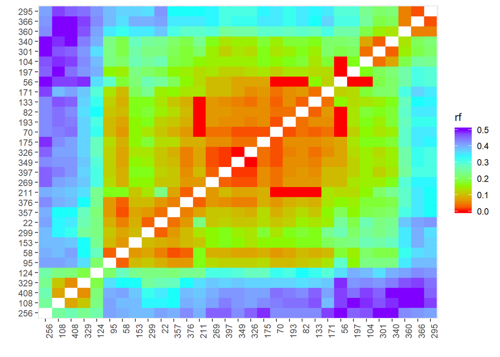

```r
LG3.1_final<- make_seq(LG3.1_ord, "force")
rf_graph_table(LG3.1_final)
```

```r
LG3.1_final
```

```
##
## Printing map:
##
## Markers               Position
##
## 256 AAT283                0.00
## 108 CB309                27.60
## 408 MgSTS511             35.29
## 329 MgSTS332             41.71
## 124 BD433                62.29
##  95 CA198                84.65
##  58 BB259                88.00
## 153 AA153C               95.09
## 299 MgSTS43             105.20
##  22 AA100               108.01
```

[output cut: 23 more lines]

```r
## Corresponds to group 7 of the original map with more tags
```

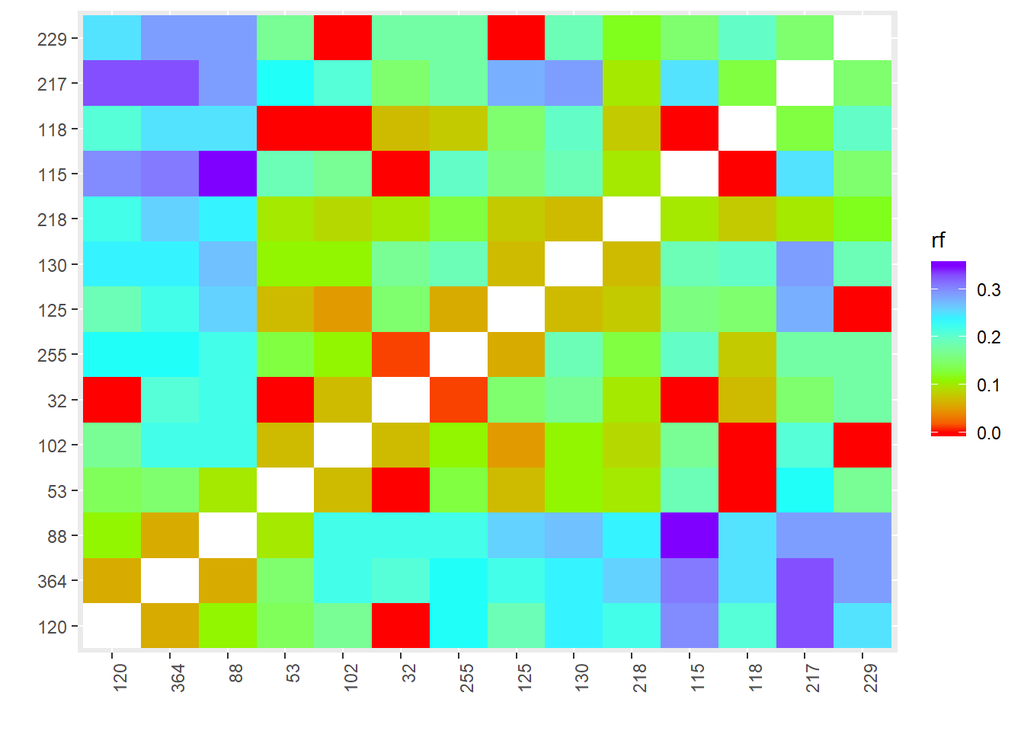

```r
LG3.2_final<- make_seq(LG3.2_ord, "force")
rf_graph_table(LG3.2_final)
```

```r
LG3.2_final
```

```
##
## Printing map:
##
## Markers                Position
##
## 120 CB156                  0.00
## 364 MgSTS574B              5.80
##  88 CA238                 12.04
##  53 BA75                  21.99
## 102 CA131                 29.01
##  32 BA384                 36.35
## 255 AAT312                37.38
## 125 BD429                 43.82
## 130 BD292                 50.66
## 218 BC586C                58.08
## 115 CB187                 68.51
## 118 CB166                 68.51
## 217 BC70                  81.46
## 229 CC387                 97.10
##
##  14 markers            log-likelihood: -1370.974
```

```r
## Corresponds to group 3 of the original map
```

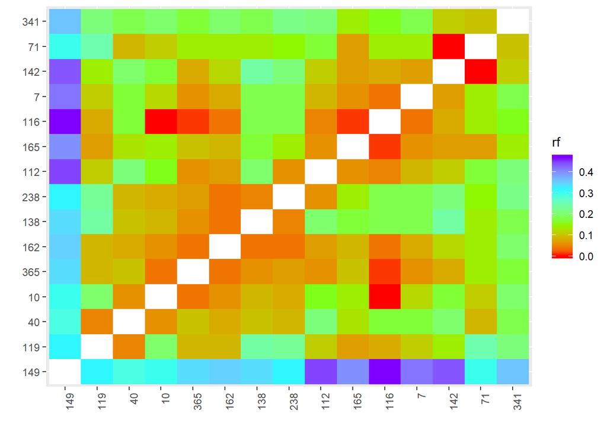

```r
LG3.3_final<- make_seq(LG3.3_ord, "force")
rf_graph_table(LG3.3_final)
```

```r
LG3.3_final
```

```
##
## Printing map:
##
## Markers                Position
##
## 149 BD68                   0.00
## 119 CB162                 38.40
##  40 BA220                 43.06
##  10 AA280                 48.88
## 365 MgSTS574a             52.80
## 162 CA258C                56.82
## 138 BD209                 60.73
## 238 CC283                 65.73
## 112 CB246                 71.57
## 165 BB103C                77.92
## 116 CB173                 78.83
##   7 AA361                 82.83
## 142 BD170                 89.90
##  71 BB119                 89.90
## 341 MgSTS34               99.72
##
##  15 markers            log-likelihood: -1407.357
```

```r
# It corresponds to group 10 of the original map
```

```r
LG4_ord <- order_seq(input.seq = LG4, n.init = 7,
                        subset.search = "twopt",
                        twopt.alg = "rcd", THRES = 3)
```

```
##
## Cross type:  f2
## Choosing initial subset using 'two-point' approach
##
## order obtained using RCD algorithm:
##
##  126 4 239 111 293 310 202 77 223 208 81 206 62 145 155 52 159 291 347 336 395 18 161 24 73 156 89 75 42 289 358 191 107 403 74 135 321 137 146
##
## calculating multipoint map using tol =  0.1 .
##
## WARNING: this operation may take a VERY long time
##
## Comparing 2520 orders:
##
##
##
##
##
## Running try algorithm
## 161 --> CA183C    : ........
##  18 --> AA166C    : .........
## 395 --> MgSTS477  : ..........
## 155 --> AA346C    : ...........
## 159 --> BA279C    : ...........
## 358 --> MgSTS347  : ...........
## 291 --> MgSTS228  : ............
## 403 --> MgSTS542B : .............
## 289 --> MgSTS132  : ..............
## 293 --> MgSTS234  : ...............
## 310 --> MgSTS455  : ...............
## 347 --> MgSTS492  : ...............
## 321 --> MgSTS262  : ................
## 111 --> CB257     : .................
##  75 --> CA399     : .................
##  89 --> CA233     : ..................
##   4 --> AA384     : ...................
## 137 --> BD239     : ....................
## 191 --> BC512     : .....................
## 206 --> BC216     : .....................
## 208 --> BC192     : .....................
```

[output cut: 42 more lines]

```
## 155 --> AA346C    : ...........................
## 239 --> CC270     : ............................
## 111 --> CB257     : .............................
##  24 --> AA66      : ..............................
## 223 --> CC531     : ...............................
## 206 --> BC216     : ................................
##  52 --> BA113     : .................................
## 208 --> BC192     : ..................................
##  77 --> CA384     : ...................................
## 191 --> BC512     : ....................................
## 310 --> MgSTS455  : .....................................
##  81 --> CA297     : ......................................
##  42 --> BA210     : .......................................
##
## Estimating final genetic map using tol = 10E-5.
```

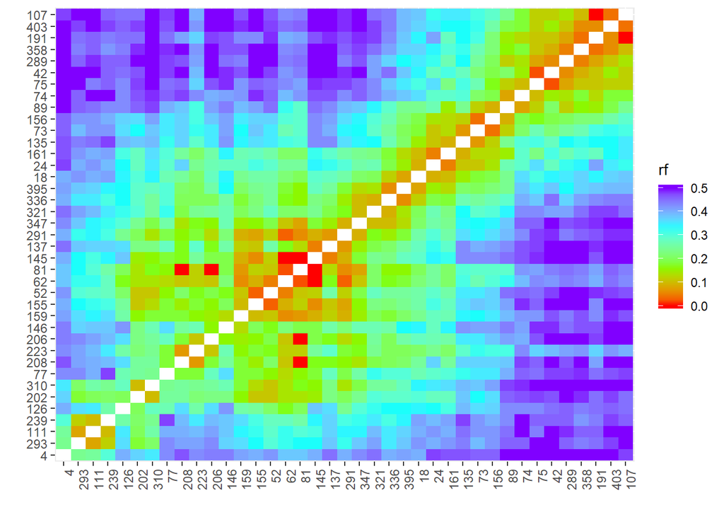

```r
LG4_ORD_all<- make_seq(LG4_ord, "force")
LG4_safe<-make_seq(LG4_ord, "safe")
rf_graph_table(LG4_ORD_all)
```

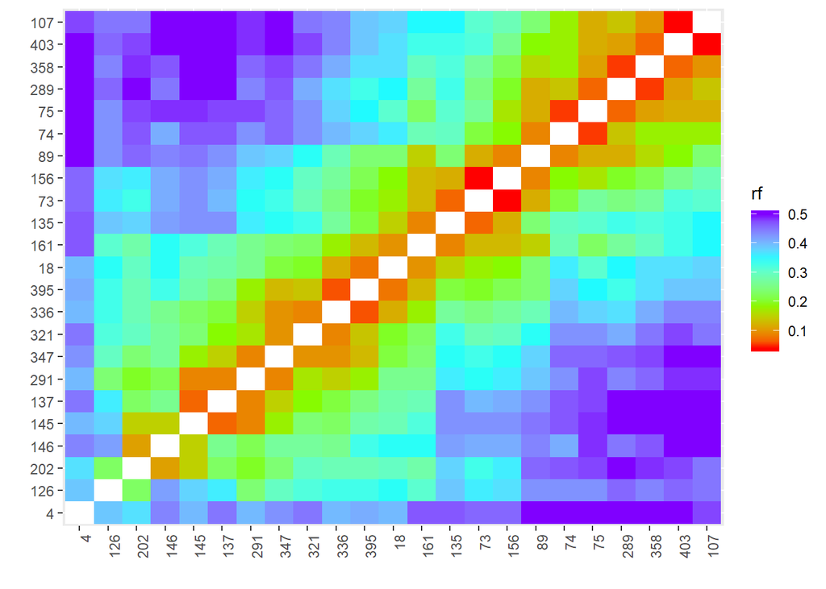

```r
rf_graph_table(LG4_safe)
```

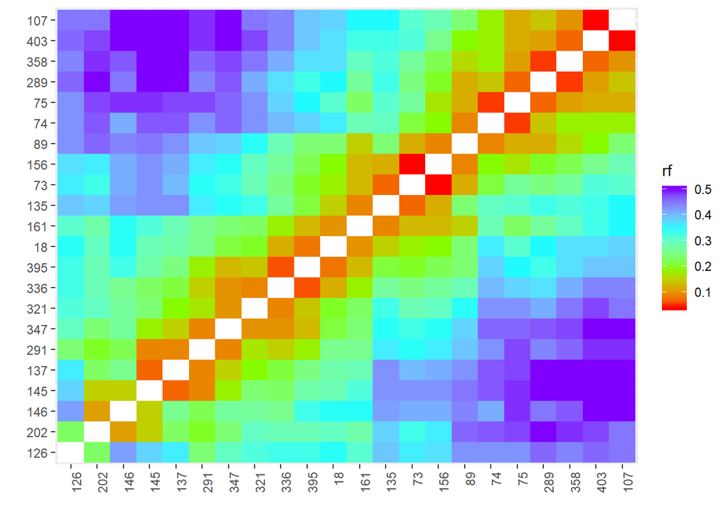

```r
LG4_final<-drop_marker(LG4_safe,4)
LG4_final<- map(LG4_final)
rf_graph_table(LG4_final)
```

```r
LG4_final
```

```
##
## Printing map:
##
## Markers                Position
##
## 126 BD411                  0.00
## 202 BC321                 24.69
## 146 BD115                 36.16
## 145 BD130                 51.20
## 137 BD239                 58.16
## 291 MgSTS228              67.13
## 347 MgSTS492              76.27
## 321 MgSTS262              86.22
## 336 MgSTS362              95.69
## 395 MgSTS477             101.28
##  18 AA166C               109.22
## 161 CA183C               119.57
## 135 BD243                128.64
##  73 CA497                135.36
## 156 AA374C               139.82
##  89 CA233                148.85
##  74 CA415                158.44
##  75 CA399                163.79
## 289 MgSTS132             171.26
## 358 MgSTS347             176.75
## 403 MgSTS542B            183.50
## 107 CB329                187.83
##
##  22 markers            log-likelihood: -2580.752
```

###################LG5##################

```r
LG5_ord <- order_seq(input.seq = LG5, n.init = 7,
                        subset.search = "twopt",
                        twopt.alg = "rcd", THRES = 3)
```

```
##
## Cross type:  f2
## Choosing initial subset using 'two-point' approach
##
## order obtained using RCD algorithm:
##
##  65 247 282 5 371 54 113 61 129 13 157 19 192 332 333
##
## calculating multipoint map using tol =  0.1 .
##
## WARNING: this operation may take a VERY long time
##
## Comparing 2520 orders:
##
##
##
##
##
## Running try algorithm
## 157 --> AA454C    : ........
## 129 --> BD316C    : .........
## 371 --> MgSTS586  : .........
## 332 --> MgSTS282A : ..........
##   5 --> AA378     : ..........
##  19 --> AA163     : ..........
## 113 --> CB230     : ...........
## 247 --> CC124     : ............
##
## LOD threshold = 3
##
## Positioned markers: 65 247 282 371 54 113 61 13 157 19 192 333
##
## Markers not placed on the map: 5 129 332
##
##
## Calculating LOD-Scores
##   5 --> AA378     : .............
## 129 --> BD316C    : .............
## 332 --> MgSTS282A : .............
##
##
## Placing remaining marker(s) at most likely position
## 332 --> MgSTS282A : .............
##   5 --> AA378     : ..............
## 129 --> BD316C    : ...............
##
## Estimating final genetic map using tol = 10E-5.
```

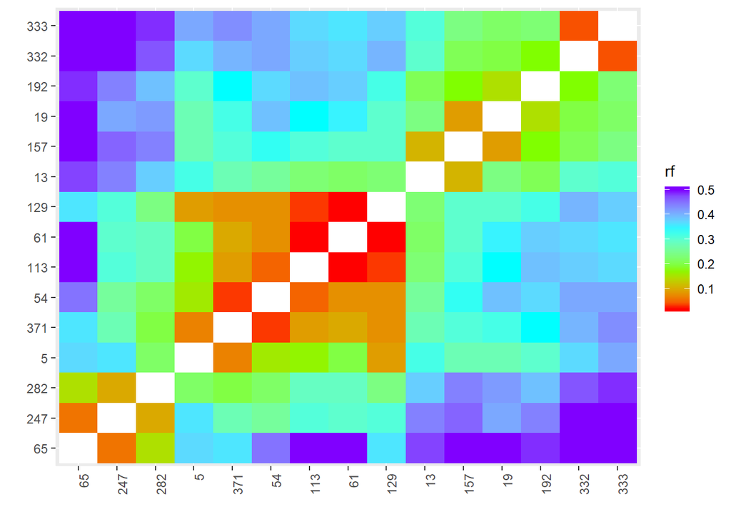

```r
LG5_ORD_all<- make_seq(LG5_ord, "force")
LG5_safe<-make_seq(LG5_ord, "safe")
rf_graph_table(LG5_ORD_all)
```

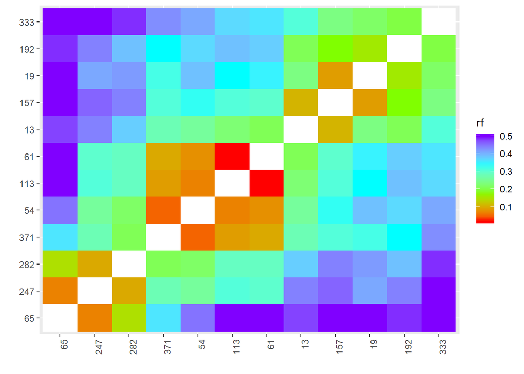

```r
rf_graph_table(LG5_safe)
```

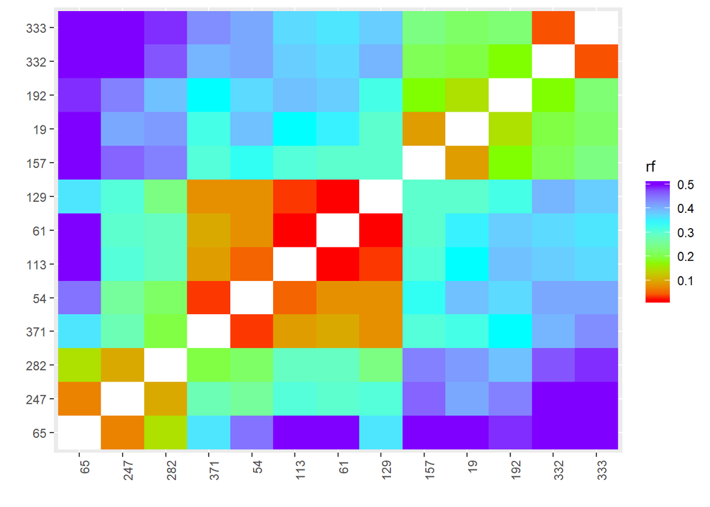

```r
LG5_final<-drop_marker(LG5_ORD_all, c(5,13))
LG5_final <- map(LG5_final)
rf_graph_table(LG5_final)
```

```r
LG5_final
```

```
##
## Printing map:
##
## Markers                Position
##
##  65 BB186                  0.00
## 247 CC124                  6.78
## 282 MgSTS40               16.82
## 371 MgSTS586              38.30
##  54 BA69                  41.56
## 113 CB230                 46.23
##  61 BB210                 47.83
## 129 BD316C                49.52
## 157 AA454C                83.65
##  19 AA163                 92.94
## 192 BC506                108.97
## 332 MgSTS282A            128.28
## 333 MgSTS255             132.35
##
##  13 markers            log-likelihood: -1628.121
```

###############LG6########

```r
LG6_ord <- order_seq(input.seq = LG6, n.init = 7,
                        subset.search = "twopt",
                        twopt.alg = "rcd", THRES = 3)
```

```
##
## Cross type:  f2
## Choosing initial subset using 'two-point' approach
##
## order obtained using RCD algorithm:
##
##  224 309 306 267 402 418 9 51 20 12 11 181 139 274 401 354 411 359 273 264 292 417 280 412 254 268 186 106 143 39 240 83 230 99 398 399 343 272 342 389 297 414 351 344 195 6 204 246 213 312 150
##
## calculating multipoint map using tol =  0.1 .
##
## WARNING: this operation may take a VERY long time
##
## Comparing 2520 orders:
##
##
```

[output cut: 92 more lines]

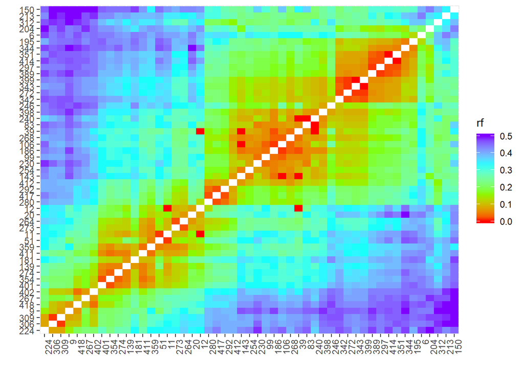

```r
LG6_ORD_all<- make_seq(LG6_ord, "force")
LG6_safe<-make_seq(LG6_ord, "safe")
rf_graph_table(LG6_ORD_all)
```

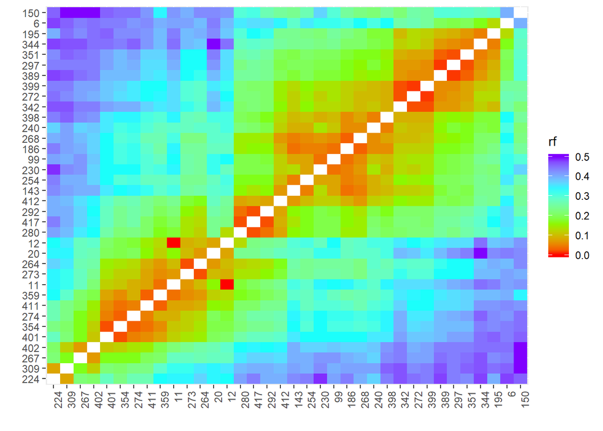

```r
rf_graph_table(LG6_safe)
```

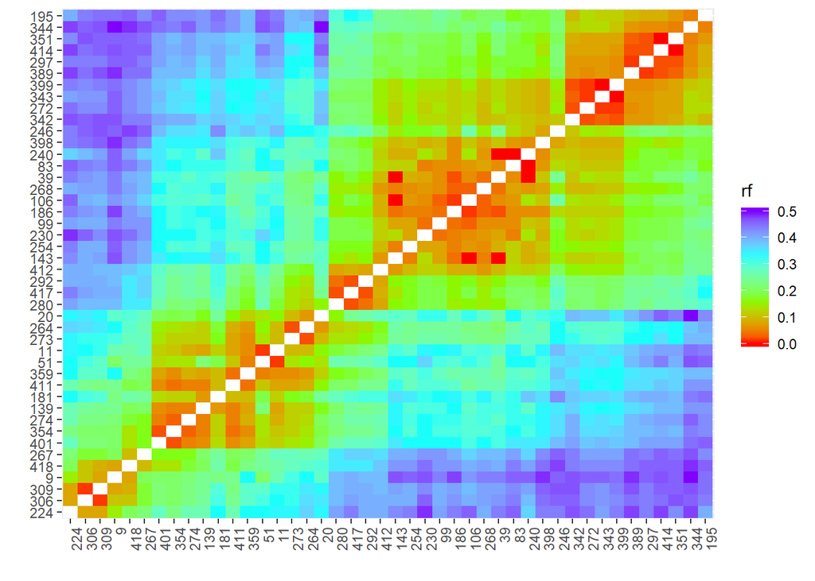

```r
LG6_final<-drop_marker(LG6_ORD_all, c(402,12,46,6,204,312,213,150))
LG6_final <- map(LG6_final)
rf_graph_table(LG6_final)
```

```r
LG6_final
```

```
##
## Printing map:
##
## Markers                Position
##
## 224 CC457                  0.00
## 306 MgSTS508               7.94
## 309 MgSTS529               9.13
##   9 AA311                 17.08
## 418 MgSTS440              24.69
## 267 MgSTS25               35.29
## 401 MgSTS545              52.49
## 354 MgSTS314              54.51
## 274 MgSTS120              57.78
## 139 BD179                 62.74
```

[output cut: 36 more lines]

##########################LG7#################################

```r
LG7_ord <- order_seq(input.seq = LG7, n.init = 7,
                        subset.search = "twopt",
                        twopt.alg = "rcd", THRES = 3)
```

```
##
## Cross type:  f2
## Choosing initial subset using 'two-point' approach
##
## order obtained using RCD algorithm:
##
##  46 68 324 14 253 409 233 166 36 151 352 374 103 327 318 368 400 363 110 180 173 172 225 80 303 187 378 316 373 94 34 188
##
## calculating multipoint map using tol =  0.1 .
##
## WARNING: this operation may take a VERY long time
##
## Comparing 2520 orders:
##
##
##
##
##
## Running try algorithm
## 400 --> MgSTS504C : ........
## 173 --> AAT211    : ........
## 151 --> BD189C    : ........
## 374 --> MgSTS538  : .........
## 373 --> MgSTS537  : ..........
## 166 --> AAT217    : ...........
## 363 --> MgSTS571  : ...........
## 187 --> CYCB      : ...........
## 316 --> MgSTS69   : ...........
## 253 --> CC338C    : ...........
## 318 --> MgSTS31   : ............
## 180 --> AAT296    : .............
## 303 --> MgSTS59   : .............
## 327 --> MgSTS330  : ..............
## 324 --> MgSTS76   : ..............
## 110 --> CB272     : ...............
##  94 --> CA210     : ...............
## 103 --> CA122     : ...............
##  14 --> AA246     : ................
## 233 --> CC359     : ................
##  68 --> BB167     : .................
```

[output cut: 33 more lines]

```
## 180 --> AAT296    : ....................
## 363 --> MgSTS571  : .....................
## 400 --> MgSTS504C : ......................
##  94 --> CA210     : .......................
## 110 --> CB272     : ........................
##  14 --> AA246     : .........................
##  68 --> BB167     : ..........................
##  36 --> BA314     : ...........................
## 173 --> AAT211    : ............................
##  80 --> CA305     : .............................
## 327 --> MgSTS330  : ..............................
## 225 --> CC450     : ...............................
## 316 --> MgSTS69   : ................................
##
## Estimating final genetic map using tol = 10E-5.
```

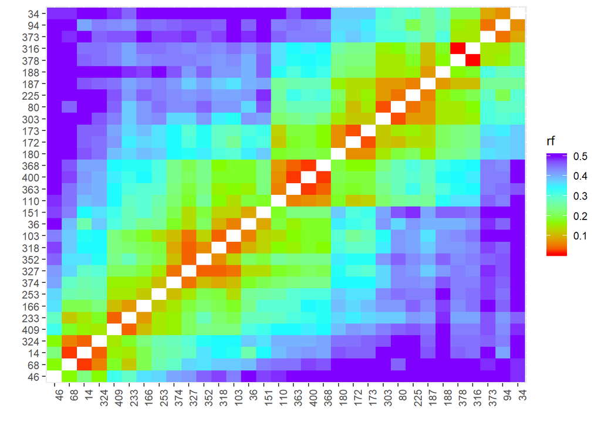

```r
LG7_ORD_all<- make_seq(LG7_ord, "force")
LG7_safe<-make_seq(LG7_ord, "safe")
rf_graph_table(LG7_ORD_all)
```

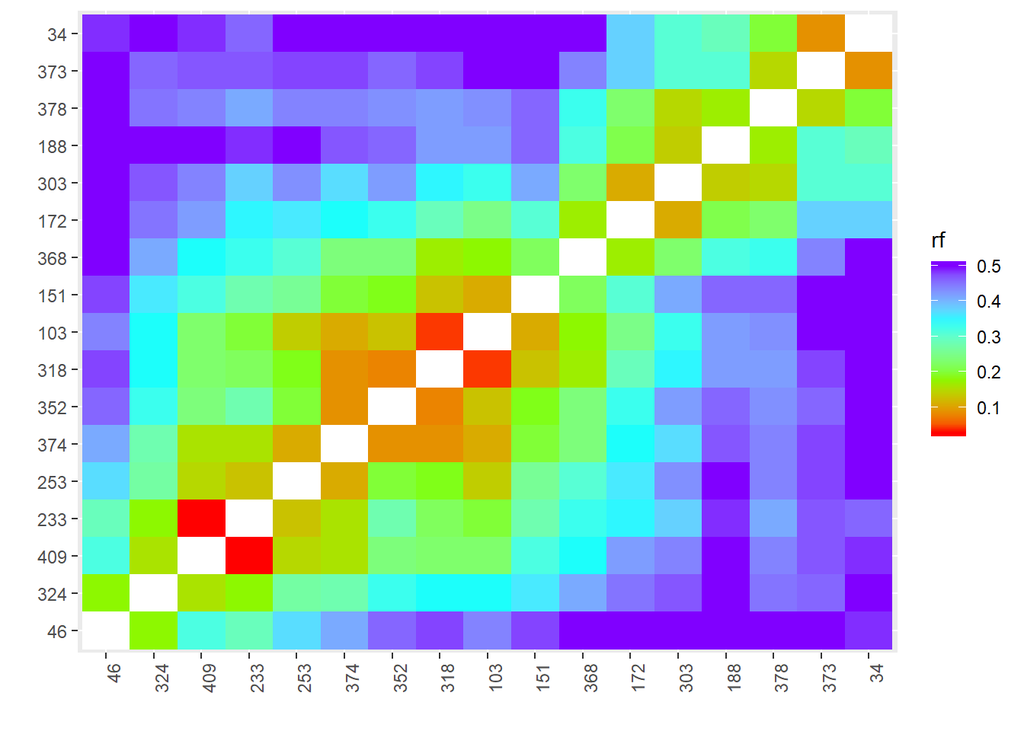

```r
rf_graph_table(LG7_safe)
```

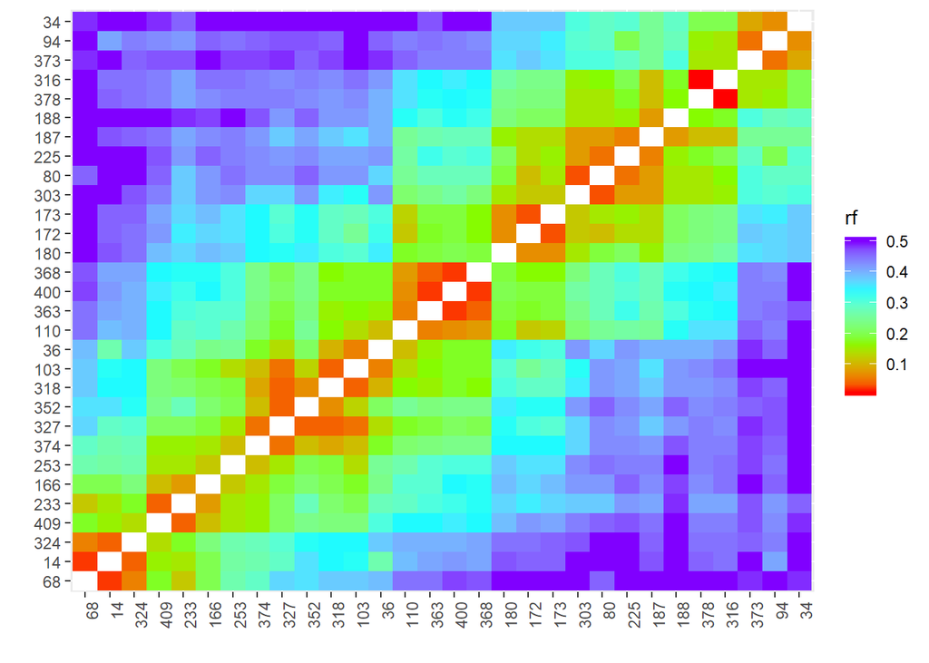

```r
LG7_final<-drop_marker(LG7_ORD_all, c(46,151))
LG7_final <- map(LG7_final)
rf_graph_table(LG7_final)
```

```r
LG7_final
```

```
##
## Printing map:
##
## Markers                Position
##
##  68 BB167                  0.00
##  14 AA246                  1.99
## 324 MgSTS76                6.08
## 409 MgSTS621              20.93
## 233 CC359                 25.09
## 166 AAT217                33.09
## 253 CC338C                45.55
## 374 MgSTS538              56.49
## 327 MgSTS330              61.32
## 352 MgSTS381              65.35
```

[output cut: 22 more lines]

##########################LG8#################################

```r
LG8_ord <- order_seq(input.seq = LG8, n.init = 7,
                        subset.search = "twopt",
                        twopt.alg = "rcd", THRES = 3)
```

```
##
## Cross type:  f2
## Choosing initial subset using 'two-point' approach
##
## order obtained using RCD algorithm:
##
##  227 174 375 215 27 222 87 29 17 67 122 96 23 37 384 257 367 160 59 214 387 415 381 311 98 93
##
## calculating multipoint map using tol =  0.1 .
##
## WARNING: this operation may take a VERY long time
##
## Comparing 2520 orders:
##
##
##
##
##
## Running try algorithm
## 381 --> MgSTS558  : ........
## 174 --> AAT222    : .........
## 384 --> MgSTS611  : .........
## 387 --> MgSTS600  : .........
## 375 --> MgSTS536  : ..........
## 311 --> MgSTS468  : ..........
## 257 --> LFY       : ...........
## 367 --> MgSTS638  : ............
##  67 --> BB176     : .............
## 122 --> CB115     : .............
##  96 --> CA196     : ..............
##  98 --> CA167     : ..............
##  23 --> AA95      : ..............
##  29 --> BA400     : ...............
## 215 --> BC83      : ...............
##  59 --> BB218     : ................
##  87 --> CA261     : .................
## 214 --> BC108     : ..................
## 222 --> CC540     : ...................
##
## LOD threshold = 3
```

[output cut: 13 more lines]

```
## 375 --> MgSTS536  : ...................
## 384 --> MgSTS611  : ...................
##
##
## Placing remaining marker(s) at most likely position
## 384 --> MgSTS611  : ...................
##  29 --> BA400     : ....................
## 174 --> AAT222    : .....................
## 375 --> MgSTS536  : ......................
##  96 --> CA196     : .......................
##  67 --> BB176     : ........................
## 222 --> CC540     : .........................
##  98 --> CA167     : ..........................
##
## Estimating final genetic map using tol = 10E-5.
```

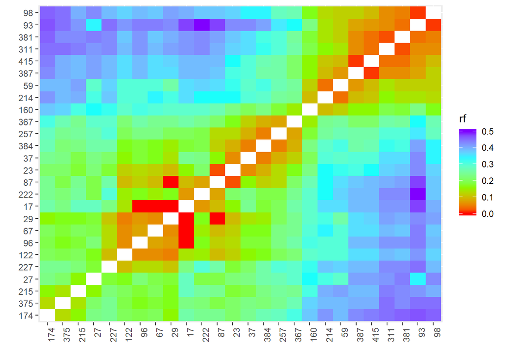

```r
LG8_ORD_all<- make_seq(LG8_ord, "force")
LG8_safe<-make_seq(LG8_ord, "safe")
rf_graph_table(LG8_ORD_all)
```

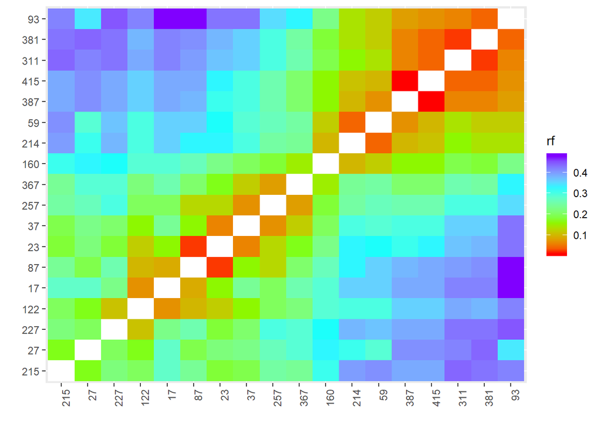

```r
rf_graph_table(LG8_safe)
```

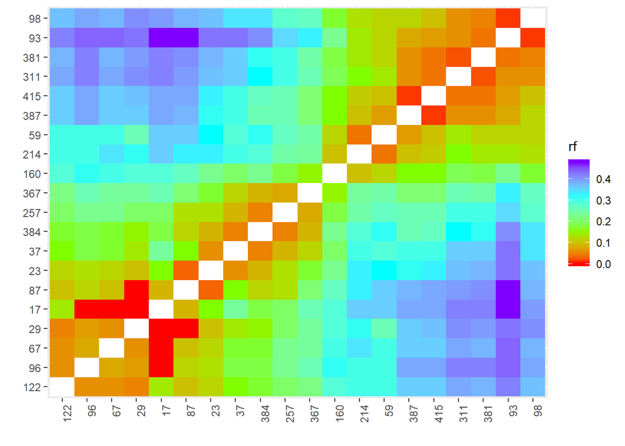

```r
LG8_final<-drop_marker(LG8_ORD_all, c(222,227,375,174,215,27))
LG8_final <- map(LG8_final)
rf_graph_table(LG8_final)
```

```r
LG8_final
```

```
##
## Printing map:
##
## Markers               Position
##
## 122 CB115                 0.00
##  96 CA196                 5.88
##  67 BB176                14.13
##  29 BA400                20.39
##  17 AA167                20.39
##  87 CA261                29.49
##  23 AA95                 32.37
##  37 BA311                38.83
## 384 MgSTS611             43.67
## 257 LFY                  48.97
## 367 MgSTS638             56.76
## 160 BA396C               72.71
## 214 BC108                82.70
##  59 BB218                86.34
## 387 MgSTS600             93.07
## 415 MgSTS470             94.30
## 311 MgSTS468             98.50
## 381 MgSTS558            100.14
##  93 CA217               103.86
##  98 CA167               105.31
##
##  20 markers            log-likelihood: -1841.566
```

##########################LG9#################################

```r
LG9_ord <- order_seq(input.seq = LG9, n.init = 7,
                        subset.search = "twopt",
                        twopt.alg = "rcd", THRES = 3)
```

```
##
## Cross type:  f2
## Choosing initial subset using 'two-point' approach
##
## order obtained using RCD algorithm:
##
##  260 21 249 127 279 334 262 385 362 350 105 134 60
##
## calculating multipoint map using tol =  0.1 .
##
## WARNING: this operation may take a VERY long time
##
## Comparing 2520 orders:
##
##
##
##
##
## Running try algorithm
## 385 --> MgSTS632  : ........
## 334 --> MgSTS350  : .........
## 350 --> MgSTS500  : ..........
## 127 --> BD371     : ...........
## 134 --> BD251     : ...........
##  21 --> AA137     : ...........
##
## LOD threshold = 3
##
## Positioned markers: 249 21 260 279 334 262 385 362 350 105 60
##
## Markers not placed on the map: 127 134
##
##
## Calculating LOD-Scores
## 127 --> BD371     : ............
## 134 --> BD251     : ............
##
##
## Placing remaining marker(s) at most likely position
## 127 --> BD371     : ............
## 134 --> BD251     : .............
##
## Estimating final genetic map using tol = 10E-5.
```

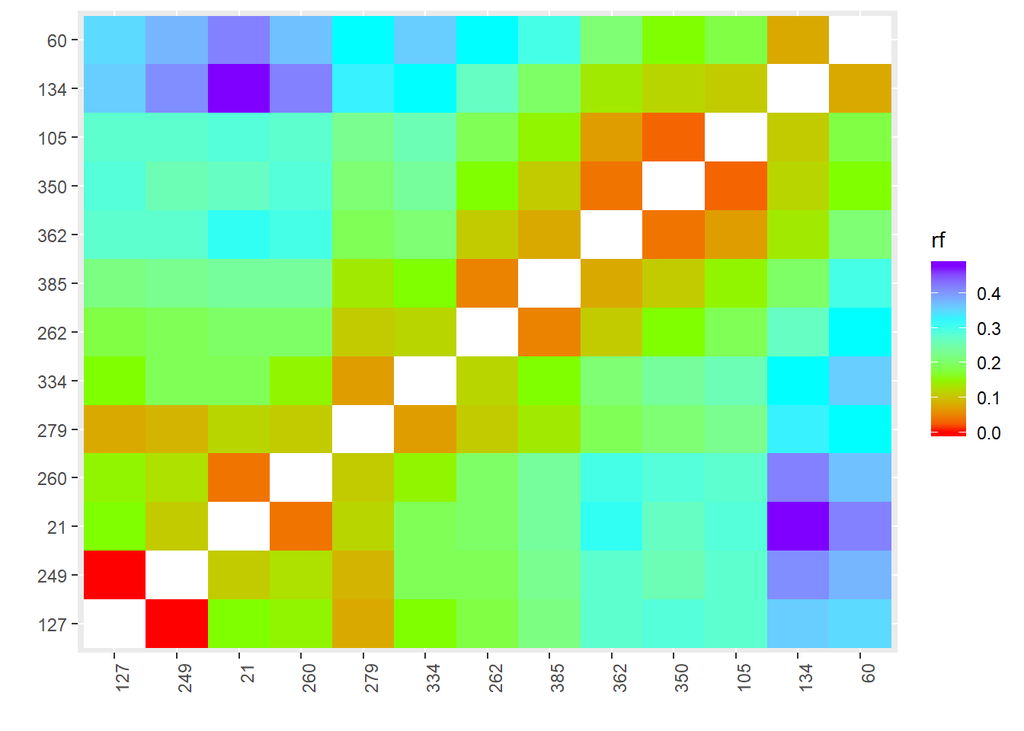

```r
LG9_final<- make_seq(LG9_ord, "force")
LG9_safe<-make_seq(LG9_ord, "safe")
rf_graph_table(LG9_final)
```

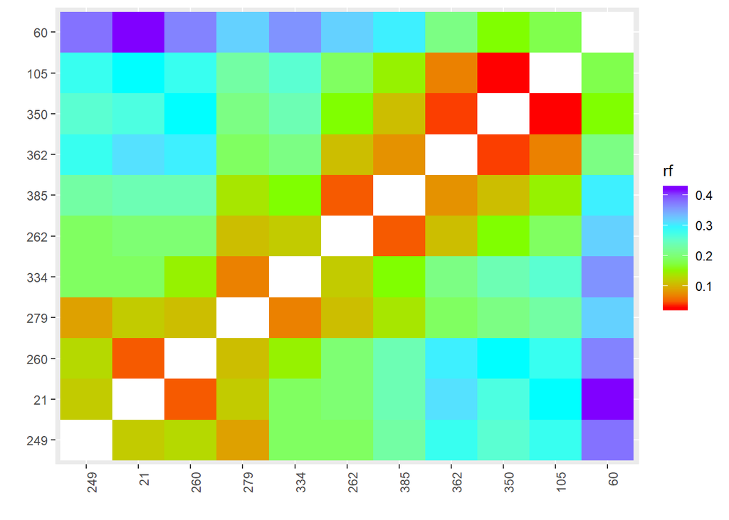

```r
rf_graph_table(LG9_safe)
```

```r
LG9_final
```

```
##
## Printing map:
##
## Markers               Position
##
## 127 BD371                 0.00
## 249 CC93                  0.00
##  21 AA137                11.67
## 260 MgSTS17              16.18
## 279 MgSTS133             27.07
## 334 MgSTS350             34.28
## 262 MgSTS18              46.66
## 385 MgSTS632             52.02
## 362 MgSTS578             59.97
## 350 MgSTS500             63.93
## 105 CA75                 66.47
## 134 BD251                77.28
##  60 BB216                85.00
##
##  13 markers            log-likelihood: -1469.361
```

##########################LG10#################################

```r
LG10_ord <- order_seq(input.seq = LG10, n.init = 7,
                        subset.search = "twopt",
                        twopt.alg = "rcd", THRES = 3)
```

```
##    Length of sequence  LG10  is less than n.init
##    Returning the best order using compare function:
## WARNING: this operation may take a VERY long time
##
## Comparing 360 orders:
##
##
```

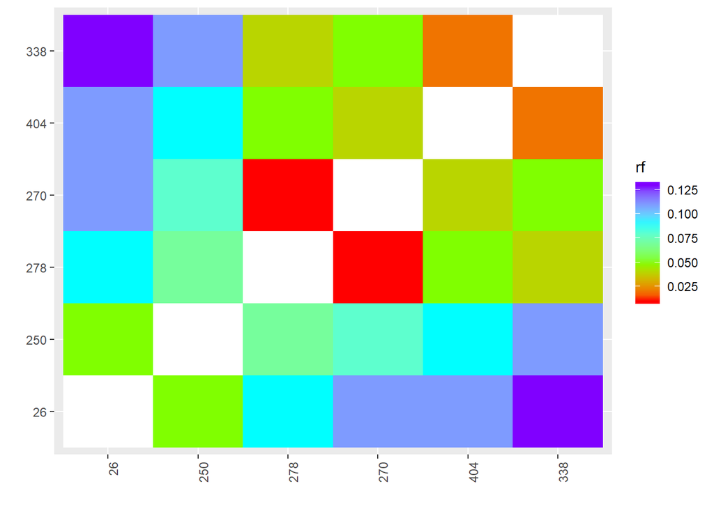

```r
LG10_final<- make_seq(LG10_ord, "force")
rf_graph_table(LG10_final)
```